# GR5320_Project

Tianyao Xu(tx2167),Xiaojie Wei(xw2536), YanziShen(ys3088)

2018-12-20

### Step 1: Load Data (Equities in Portfolio)

We download our data from “Yahoo Finance” by using “tidyquant” package. Users can choose any tickers they want. Here,for mathematical descriptions of model, we use “XOM”&“INTC” as example.Users can replace all the “XOM”&“INTC” in this Rmd file with tickers they want.

```r
library(ggplot2)
library(MASS)
library(quantmod)
if (!require("quantmod")) {
    install.packages("quantmod")
    library(quantmod)
}
if (!require("tidyquant")) {
    install.packages("tidyquant")
    library(tidyquant)
}
```

**Tickers**

Stock price is orderd from newest to oldest. We set the start date of data is “1990-01-01”, and the end date is system date.

```r
XOM <- tq_get("XOM", get = "stock.prices",from="1990-01-01")
XOM <- XOM[order(XOM$date,decreasing = T),]
INTC <- tq_get("INTC", get = "stock.prices",from="1990-01-01")
INTC <- INTC[order(INTC$date,decreasing = T),]
```

**Options**

We download data implied volatility of options from bloomberg.

```r
imp_vol <- read.csv("../data/volatility.csv")
imp_vol$Date <- as.Date(imp_vol$Date,"%m/%d/%Y")
intc.option <- read.csv("~/GitHub/risk-mgmt-GroupX/data/intc-option.csv")
xom.option <- read.csv("~/GitHub/risk-mgmt-GroupX/data/xom-option.csv")
```

### Step 2: Source function and files

We calculated parameters that calibrated to historical stock prices.

```r
# calculate parameter for stocks/portfolio return
source("../code/parameter/winEstGBM.R")
source("../code/parameter/expEstGBM.R")
source("../code/parameter/winEstGBM2.R") #estimated parameters and rho for two stocks
```

```r
# historical VaR&ES
source("../code/stock/HVaR.R")        #for individual stock & portfolio1 two stocks
source("../code/stock/HES.R")         #for individual stock & portfolio1 two stocks
source("../code/Option_HVaR.R")       #for portfolio2 stock+options


# monte carlo VaR&ES
source("../code/stock/MC_update.R")  #for individual stock
source("../code/corrgbmsampset.R")   #for portfolio1 two stocks
source("../code/Option_MCVaR.R")      #for portfolio2 stock+options

# Parametric VaR&ES
source("../code/stock/gbmVaR.R")         #for individual stock
source("../code/stock/gbmES.R")          #for individual stock
source("../code/stocks_parametricVaR.R") #for portfolio1 two stocks
source("../code/Option_ParametricVaR.R") #for portfolio2 stock+options

# plot graph
source("../code/plotGraph.R")
source("../code/BTplot.R")

#others
source("../doc/calculation_measure.R")
source("../code/BlackScholesOption.R")

# Backtest
source("../code/BackTest.R")
source("../code/Loss.R")
```

### Step 3: Individual Stock Analysis

#### 3.0: Prepare Inputs

This part allows users to set arbitrary inputs.

```r
s1 <- XOM$adjusted
s2 <- INTC$adjusted
dRtn <- 5                                #horizon for day,eg:5 day VaR
year <- 5                                #window length, 5 years
par1 <- winEstGBM(s1,dRtn,year)          #estimated mu and sigma of stock price
par2 <- winEstGBM(s2,dRtn,year)
s0 <- 10000                              #$10,000 dollar position each day
VaRp <- 0.99
ESp <- 0.95
npaths <- 10000
```

#### 3.1: Calculate Individual Stock VaR&ES

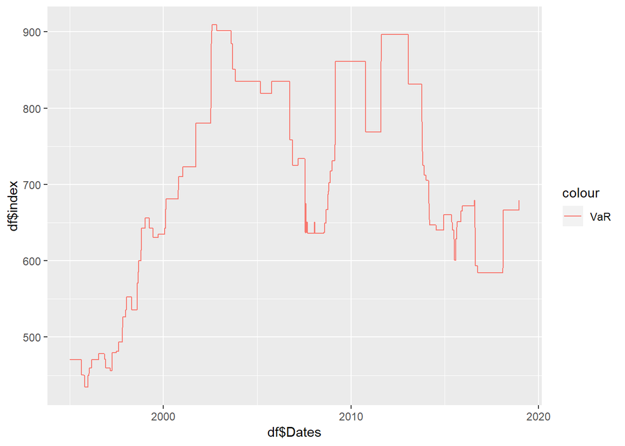

```r
# historical VaR&ES
HVaR <- HVaR_S(s1,VaRp,dRtn,year,s0)
HES <- ES_S(s1,ESp,dRtn,year,s0)
plotGraph(HVaR,XOM$date)
```

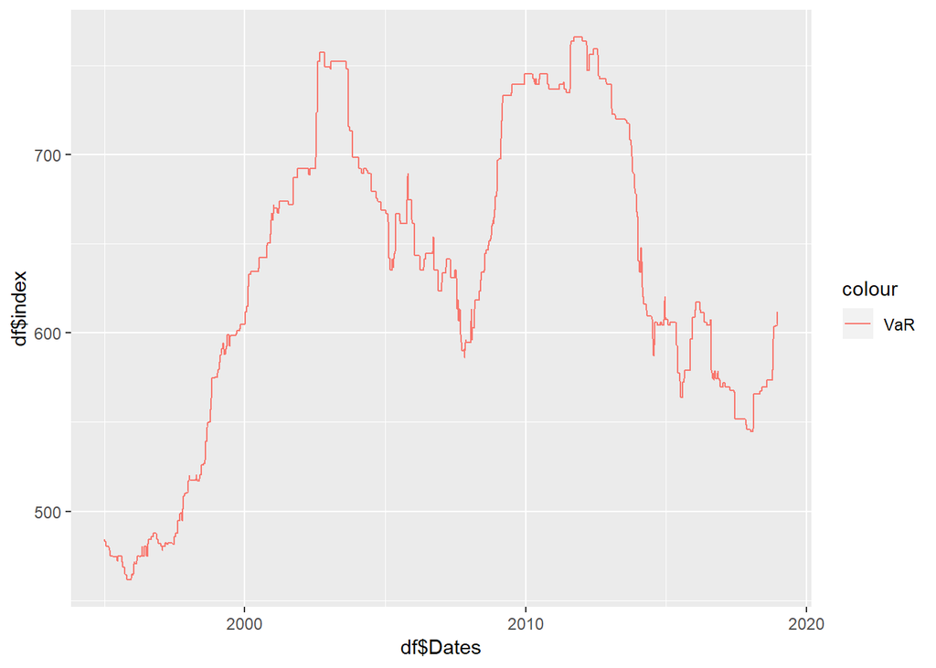

```r
plotGraph(HES,XOM$date)
```

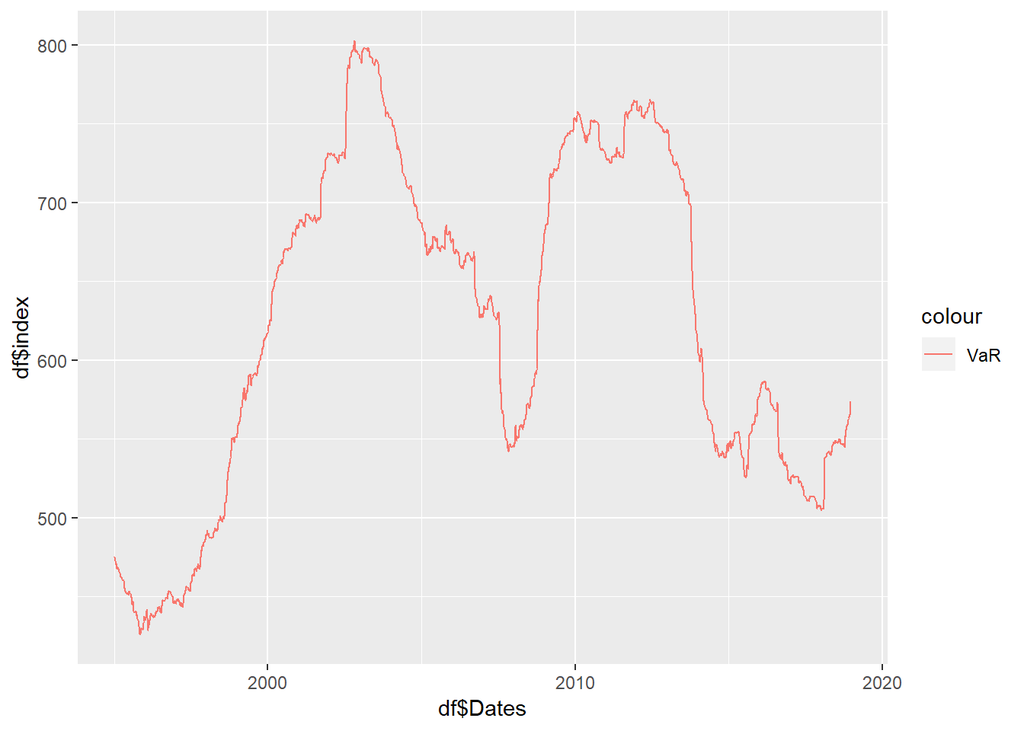

```r
# paramentric VaR
GVaR <- gbmVaR(s0,par1$mu_gbm,par1$sigma_gbm,VaRp,dRtn)
GES <- gbmES(s0,par1$mu_gbm,par1$sigma_gbm,ESp,dRtn)
plotGraph(GVaR,XOM$date)
```

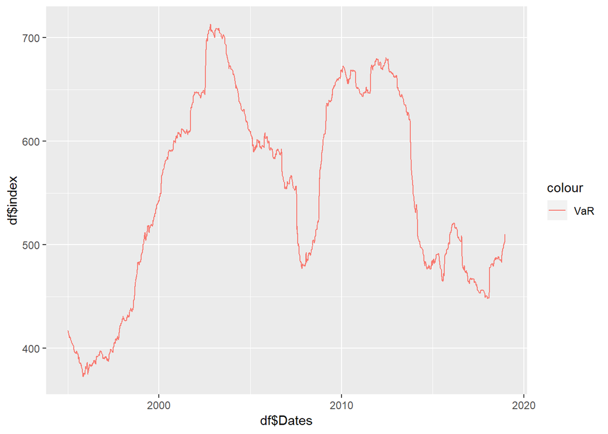

```r
plotGraph(GES,XOM$date)
```

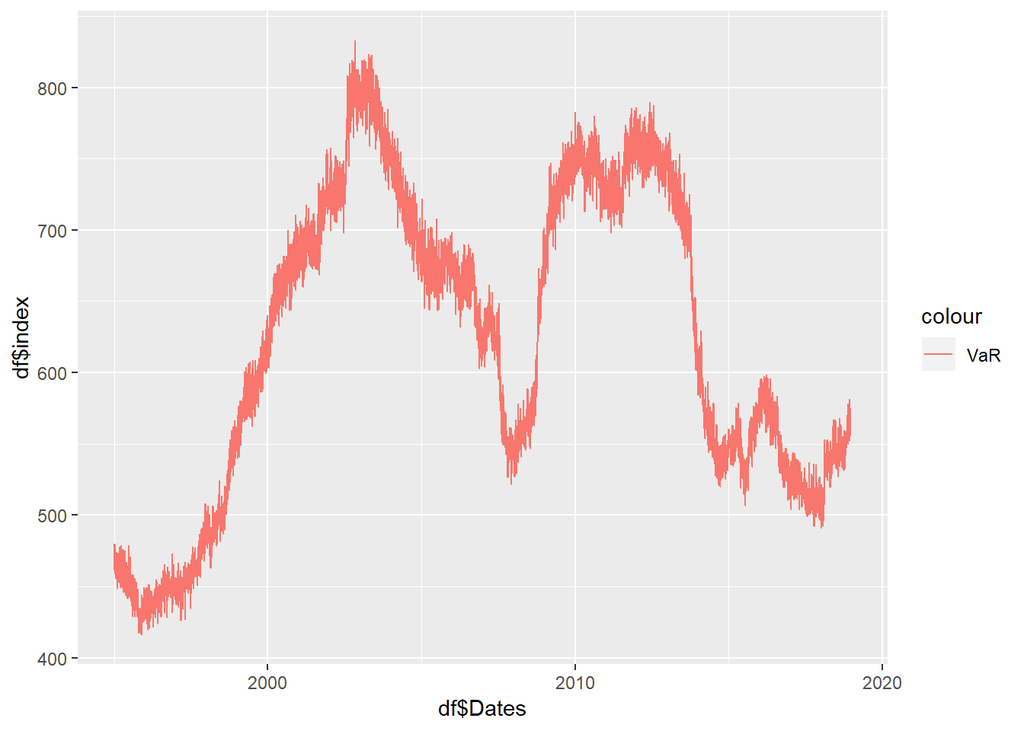

```r
# Monte Carlo VaR
MVaR <- MCVaR(s0, par1$mu_gbm, par1$sigma_gbm, VaRp, npaths,year,dRtn)
MES <- MCES(s0, par1$mu_gbm, par1$sigma_gbm, ESp, npaths,year,dRtn)
plotGraph(MVaR,XOM$date)
```

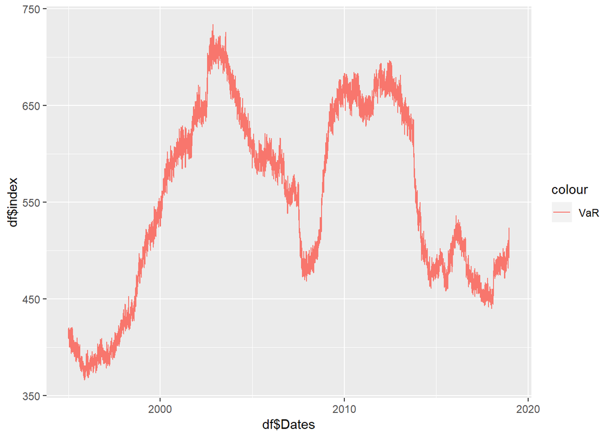

```r
plotGraph(MES,XOM$date)
```

### Step 4: Portfolio Analysis

#### 4.1: Part 1: Portfolio = weight1*s1 + weight2*s2

##### 4.1.0: Prepare Inputs

```r
# This part is allowed to set arbitrary inputs
source("../code/portfolio_value.R")
prices <- comb.col(s1,s2)
positions <- c("long","long")
wgt <- c(0.6,0.4)
v0 <- 10000

# wgt <- c(156/(156+200),200/(156+200))
# price_date <- cbind.data.frame(XOM$date,prices)
# colnames(price_date) <- c("date","s1","s2")
```

```r
port_value <- portfolio_px(prices,wgt,positions,v0)

#estimated parameters of whole portfolio
port_par1 <- winEstGBM(port_value,dRtn,year)

#estimated parameters of each part and covariance matrix in portfolio
port_par2 <- winEstGBM2(prices,dRtn,year)

shares <- v0*wgt/prices[1,]      #shares number of s1,s2 (notes:set shares number using the newest price)
s0 <- prices[1,]                 #price at start day(eg,1997-01-01)
mu <- port_par2$mu_gbm
sigma <- port_par2$sigma_gbm
rho <- port_par2$rho
```

##### 4.1.1: Calculate Portfolio VaR&ES

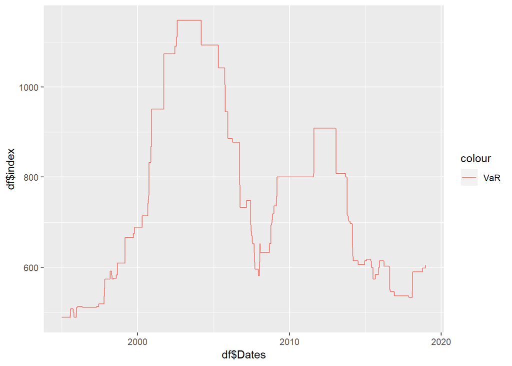

```r
# Historical VaR&ES
port_HVaR <- HVaR_S(port_value,VaRp,dRtn,year,v0)
port_HES <- ES_S(port_value,ESp,dRtn,year,v0)

#here,using XOM date for plot because the date of portfolio is same with XOM and INTC
plotGraph(port_HVaR,XOM$date)
```

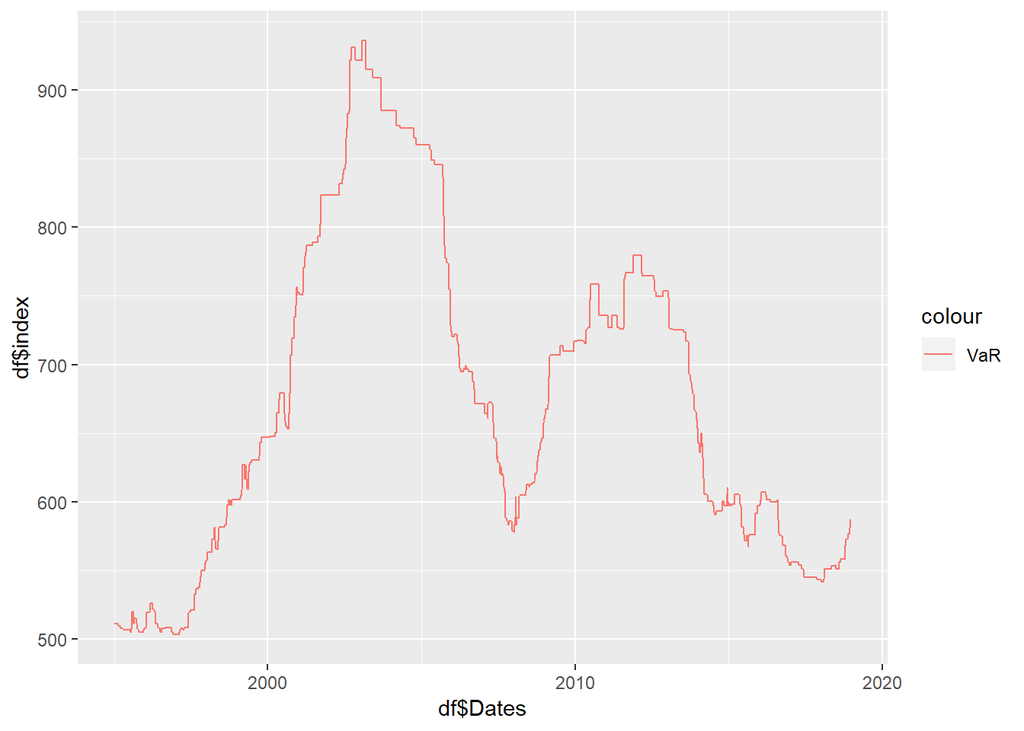

```r
plotGraph(port_HES,XOM$date)
```

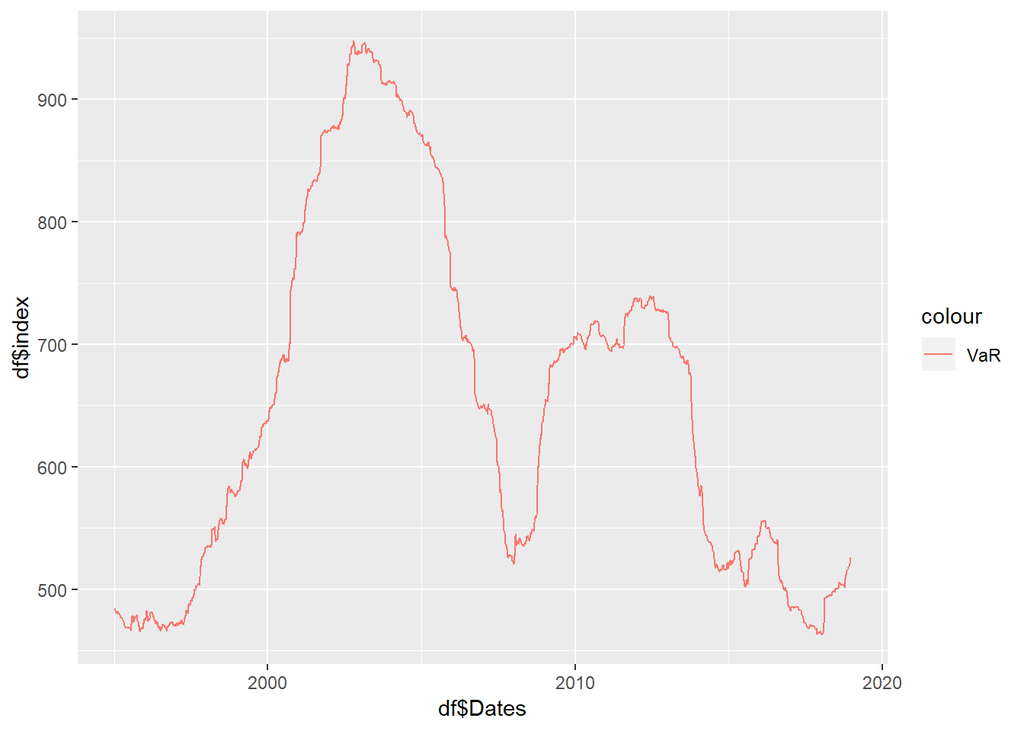

```r
# Parametric VaR1(&ES): portfolio follows GBM
GVaR_p1 <- gbmVaR(v0,port_par1$mu_gbm,port_par1$sigma_gbm,VaRp,dRtn)
GES_p1 <- gbmES(v0,port_par1$mu_gbm,port_par1$sigma_gbm,ESp,dRtn)
plotGraph(GVaR_p1,XOM$date)
```

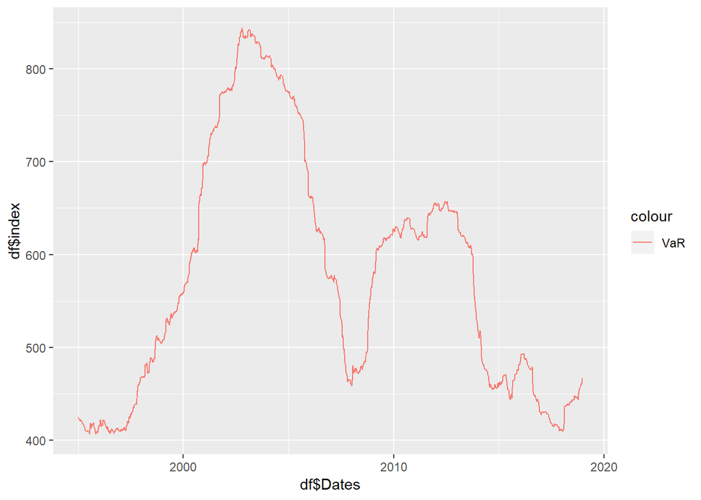

```r
plotGraph(GES_p1,XOM$date)
```

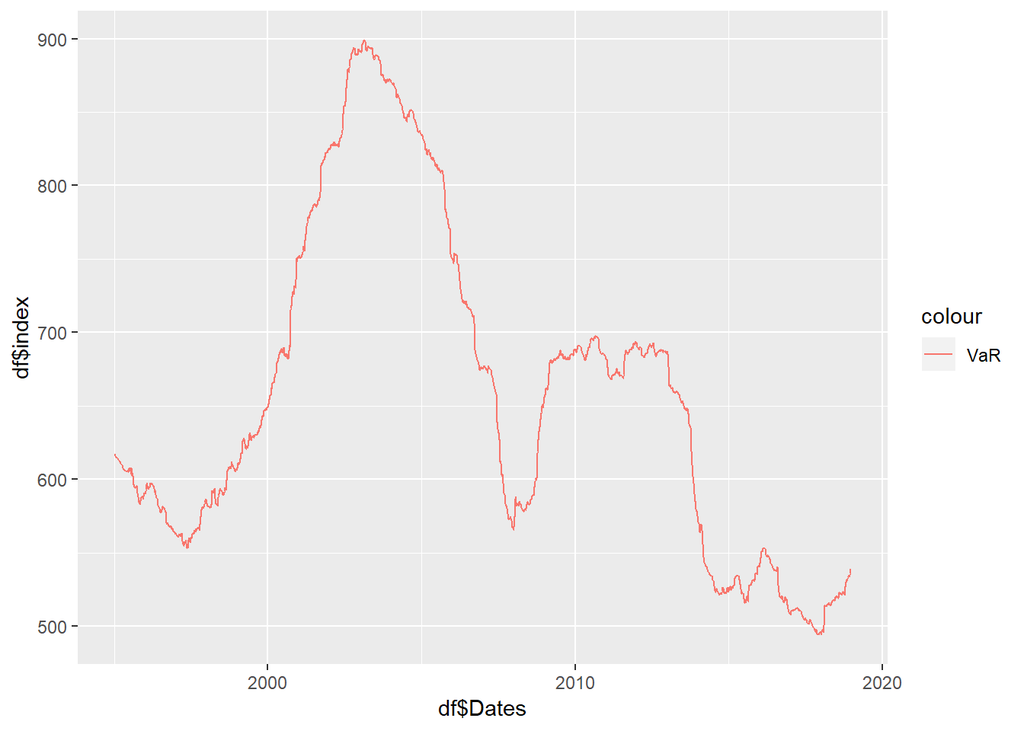

```r
# Parametric VaR2: underlying stock follows GBM
PVaR_p1 <- parametricVaR(shares,s0,mu,sigma,rho,VaRp,dRtn,v0)
plotGraph(PVaR_p1,INTC$date)
```

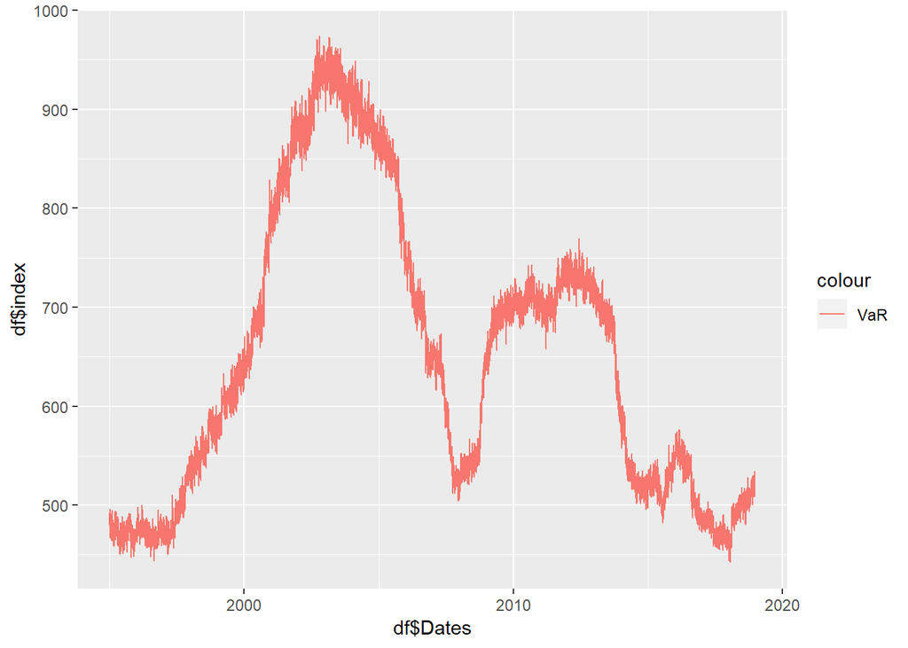

```r
# Monte Carlo VaR1: portfolio follows GBM
port_MVaR <- MCVaR(v0, port_par1$mu_gbm, port_par1$sigma_gbm, VaRp, npaths,year,dRtn)
port_MES <- MCES(v0, port_par1$mu_gbm, port_par1$sigma_gbm, ESp, npaths,year,dRtn)
plotGraph(port_MVaR,XOM$date)
```

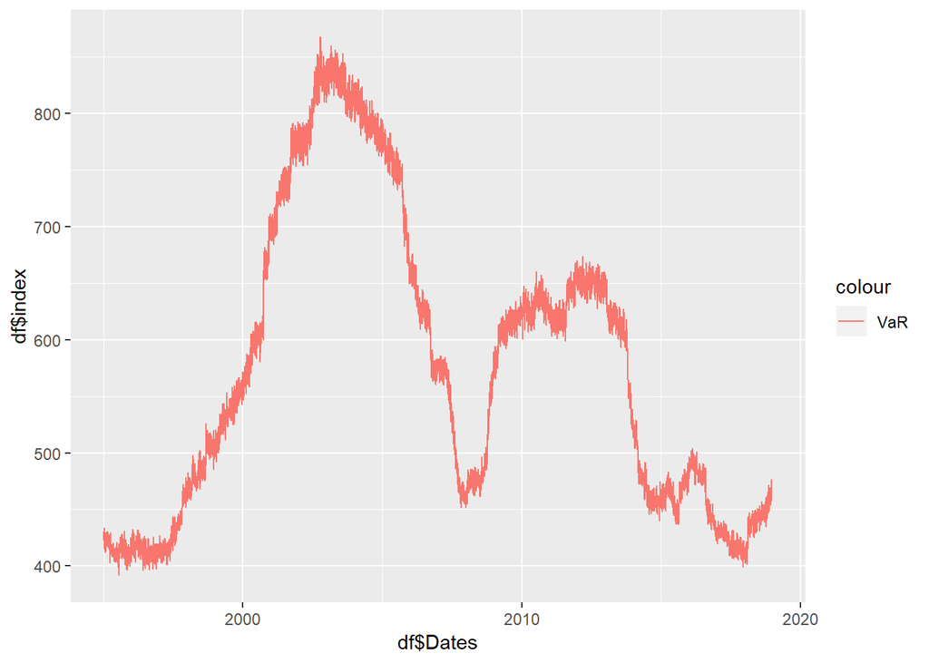

```r
plotGraph(port_MES,XOM$date)
```

```r
# Monte Carlo (underlying stock follows GBM)
# MCVaR_p1 <- MCVaR_p(v0, port_par2$mu_gbm, port_par2$sigma, port_par2$rho,shares,VaRp, npaths,year,dRtn)
# plotGraph(MCVaR_p1,INTC$date)
```

#### 4.2: Part 2: Portfolio = Stocks + Options

Here, we only use one stock, a call option of the stock and a put option of the stock.

##### 4.2.0: Prepara Inputs

```r
wgt_s <- 0.9                            #weights of stocks in portfolio
wgt_call <- 0.05                        #weights of call option in portfolio
wgt_put <- 0.05                         #weights of put option in portfolio
v0 <- 10000
VaRp <- 0.99
horizon <- 5
year <- 1
rf <- 0.005
```

```r
option <- function(option,price){
  option <- option[,c(1,ncol(option))]
  colnames(option) <- c("date","Implied_Vol")
  option$date <- as.Date(option$date,"%m/%d/%y")
  px <- price[,c(1,ncol(price))]
  option_px <- merge(transform(px,date),transform(option,date))
  return(option_px)
}

option1 <- option(xom.option,XOM)
option2 <- option(intc.option,INTC)

price1 <- option1$adjusted

maturity1 <- 252                         #1 year
maturity2 <- 252                         #1 year
strike1 <- price1
strike2 <- price1
```

```r
iv1 <- option1$Implied_Vol
iv2 <- option1$Implied_Vol

putt <- Put(price1, strike1, rf, maturity1-horizon, iv1)
calll <- Call(price1, strike2, rf, maturity2-horizon, iv2)

nstocks <- wgt_s*v0/option1$adjusted[1]
ncalls <- 0.05*v0/calll[1]
nputs <- 0.05*v0/putt[1]

mu <- par1$mu_gbm
sigma <- par1$sigma_gbm
npath <- 1000
price0<- price1[length(price1)]
s0 <- 10000
```

```r
# # Historical VaR&ES
# OP_HVaR <- Option_HVaR(price1, price1, year, rf, nstocks, iv1, strike1, maturity1,
#                      iv2, strike2, maturity2, ncalls, nputs,
#                      VaRp, horizon)
#
# OP_HES <- Option_HVaR(price1, price1, year, rf, nstocks, iv1, strike1, maturity1,
#                      iv2, strike2, maturity2, ncalls, nputs,
#                      ESp, horizon)
# plotGraph(OP_HVaR,option1$date)
# plotGraph(OP_HES,option1$date)
#
#
# # Parametric
# # s0 <- price1
# OP_PVaR <- Option_ParametricVaR(price0,s0, mu, sigma, rf, nstocks, iv1, maturity1,
#                       iv2, maturity2, ncalls, nputs,
#                       VaRp, horizon)
# plotGraph(OP_PVaR,option1$date)
#
#
# # Monte Carlo VaR&ES
# OP_MCVaR <- Option_MCVaR(s0, mu, sigma, rf, nstocks, iv1, maturity1,
#                       iv2, maturity2, ncalls, nputs,VaRp, horizon, npath)
# plotGraph(OP_MCVaR,option1$date)
```

### Step 5: Back Test

#### 5.1: Individual Stock

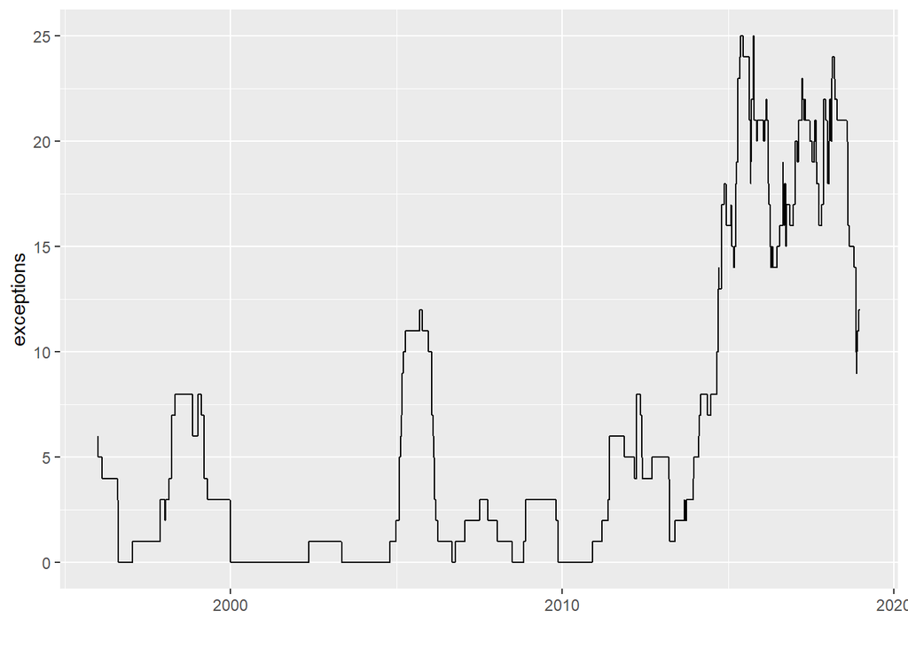

```r
#Backtest of parametric VaR
GBT<-BackTest(s1,GVaR,1,10000)
BTplot(GBT,XOM$date)
```

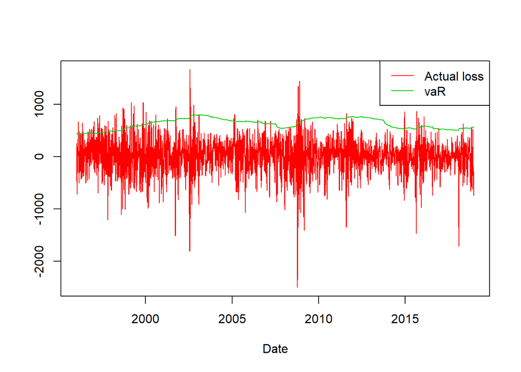

```r
GLoss<-Loss(s1,GVaR,1,10000)
plot(XOM$date[1:length(GLoss[,1])],GLoss[,1],type="l",col="2",xlab = "Date",ylab = "")
lines(XOM$date[1:length(GLoss[,1])],GLoss[,2],y=,type="l",col="3")
legend("topright",legend=c("Actual loss","vaR"),col=2:3,lty=1)
```

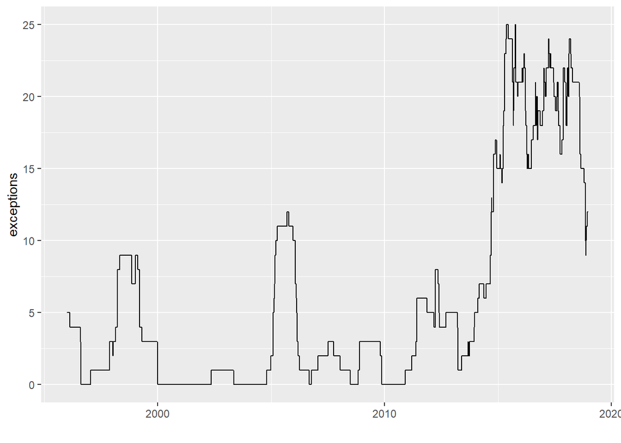

```r
#Backtest of Monte Carlo VaR
MBT<-BackTest(s1,MVaR,1,10000)
BTplot(MBT,XOM$date)
```

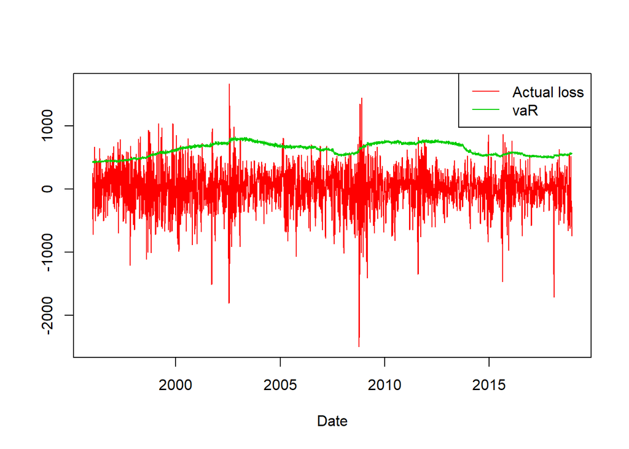

```r
MLoss<-Loss(s1,MVaR,1,10000)
plot(XOM$date[1:length(GLoss[,1])],MLoss[,1],type="l",col="2",xlab = "Date",ylab = "")
lines(XOM$date[1:length(GLoss[,1])],MLoss[,2],y=,type="l",col="3")
legend("topright",legend=c("Actual loss","vaR"),col=2:3,lty=1)
```

#### 5.2: Two stocks in the portfolio

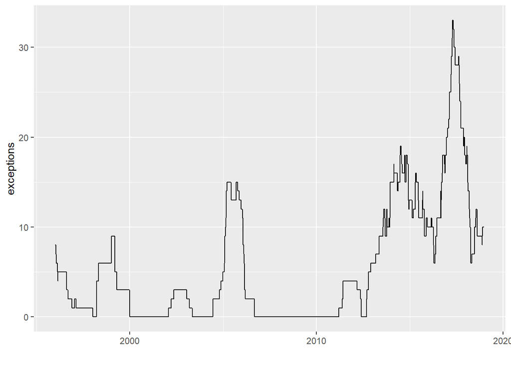

```r
#Backtest of Parametric VaR portfolio follows GBM
GBT_p1<-BackTest(port_value,GVaR_p1,1,10000)
BTplot(GBT_p1,XOM$date)
```

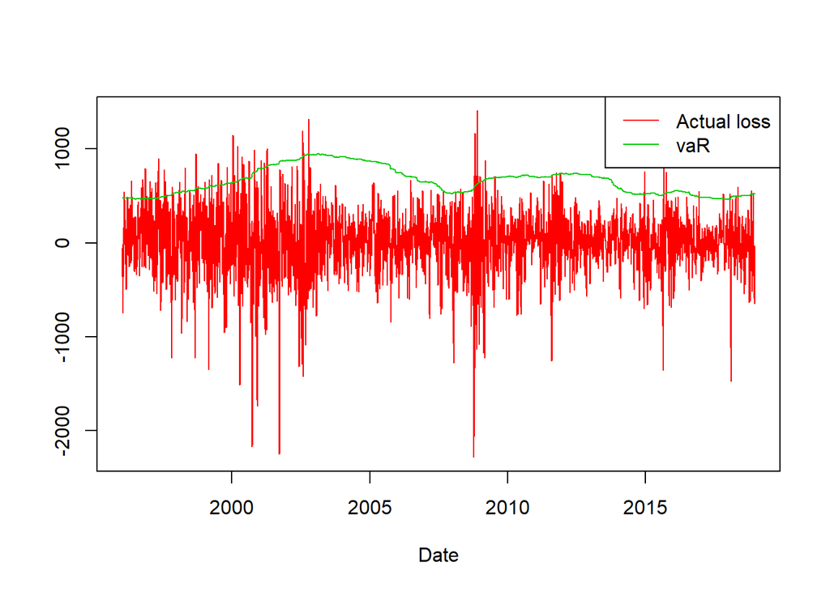

```r
GLoss_p1<-Loss(port_value,GVaR_p1,1,10000)
plot(XOM$date[1:length(GLoss_p1[,1])],GLoss_p1[,1],type="l",col="2",xlab = "Date",ylab = "")
lines(XOM$date[1:length(GLoss_p1[,1])],GLoss_p1[,2],y=,type="l",col="3")
legend("topright",legend=c("Actual loss","vaR"),col=2:3,lty=1)
```

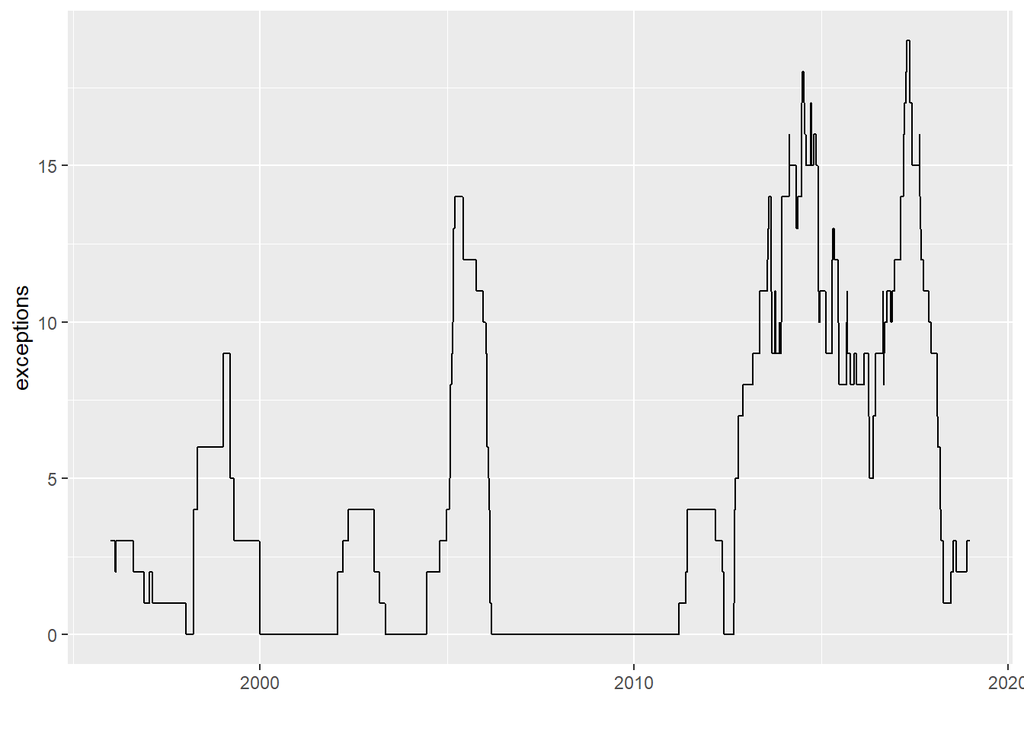

```r
#Back Test of  Parametric VaR underlying follows GBM
PBT_p1<-BackTest(port_value,PVaR_p1,1,10000)
BTplot(PBT_p1,XOM$date)
```

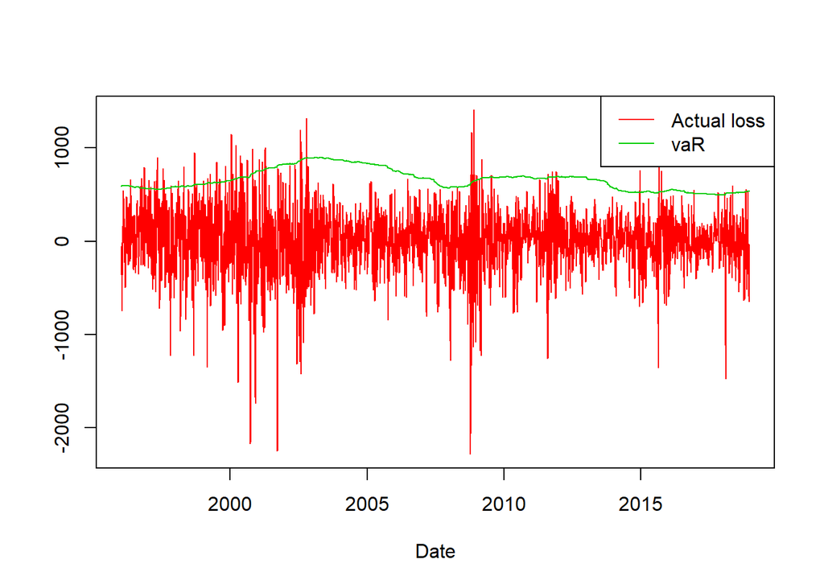

```r
PLoss_p1<-Loss(port_value,PVaR_p1,1,10000)
plot(XOM$date[1:length(PLoss_p1[,1])],PLoss_p1[,1],type="l",col="2",xlab = "Date",ylab = "")
lines(XOM$date[1:length(PLoss_p1[,1])],PLoss_p1[,2],y=,type="l",col="3")
legend("topright",legend=c("Actual loss","vaR"),col=2:3,lty=1)
```

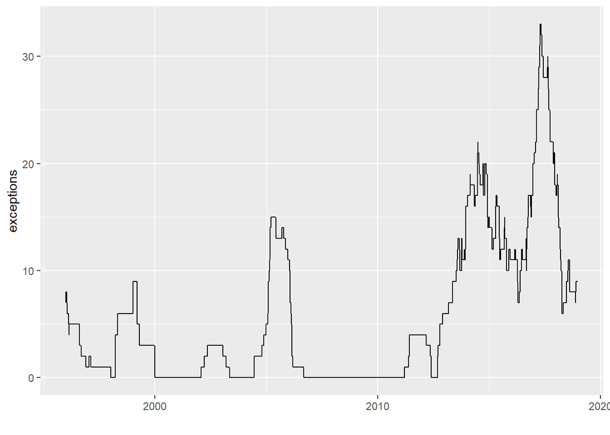

```r
#Back Test of  Monte Carlo VaR portfolio follows GBM
MBT_port<-BackTest(port_value,port_MVaR,1,10000)
BTplot(MBT_port,XOM$date)
```

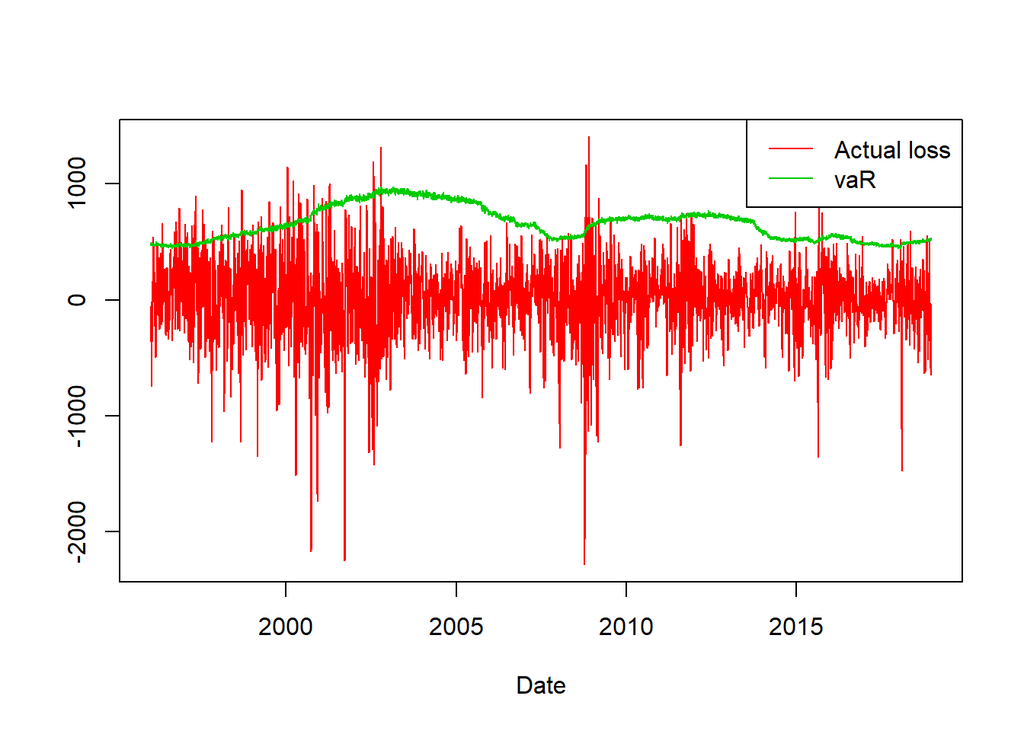

```r
MLoss_port<-Loss(port_value,port_MVaR,1,10000)
plot(XOM$date[1:length(MLoss_port[,1])],MLoss_port[,1],type="l",col="2",xlab = "Date",ylab = "")
lines(XOM$date[1:length(MLoss_port[,1])],MLoss_port[,2],y=,type="l",col="3")
legend("topright",legend=c("Actual loss","vaR"),col=2:3,lty=1)
```

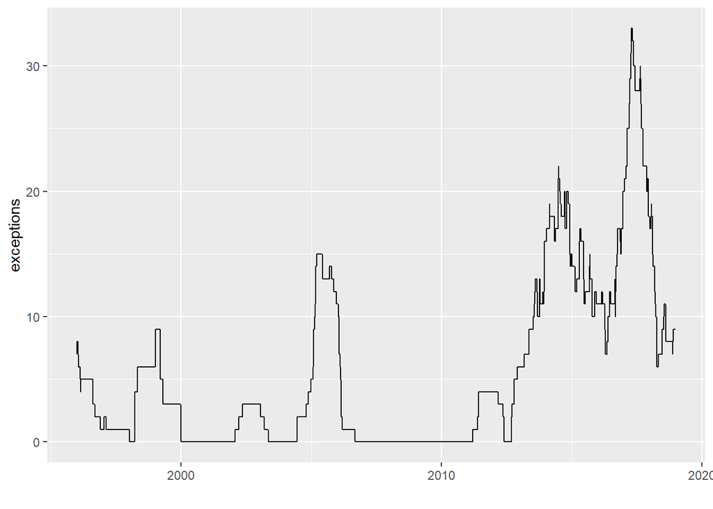

```r
#Back Test of  Monte Carlo VaR underlying follows GBM
MBT_p1<-BackTest(port_value,port_MVaR,1,10000)
BTplot(MBT_p1,XOM$date)
```

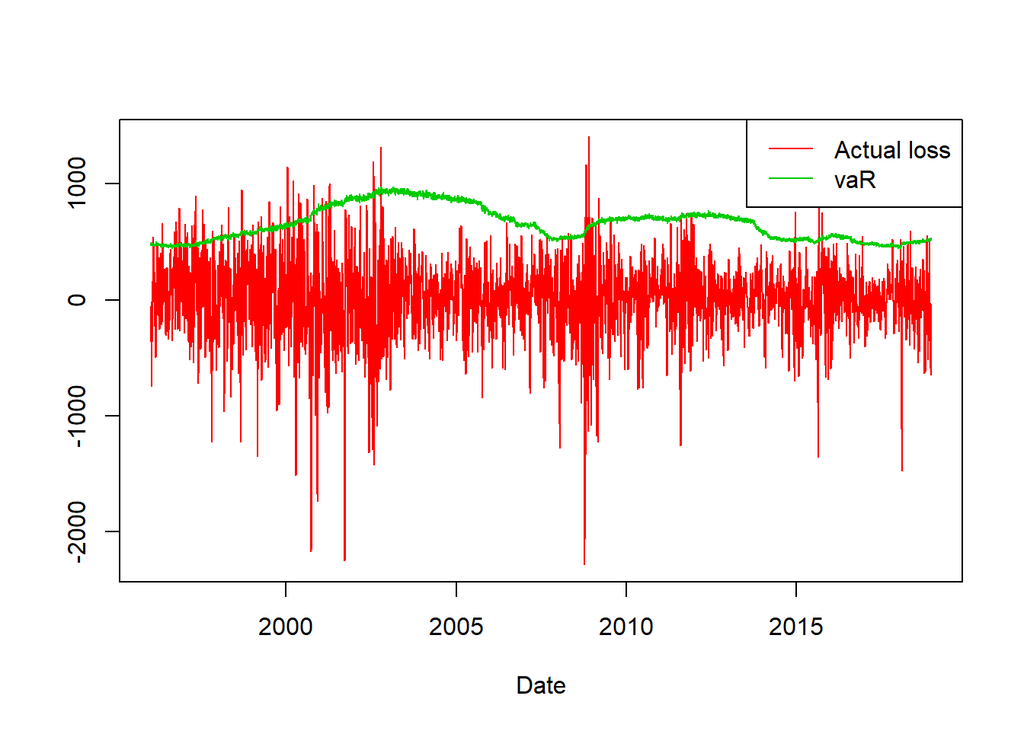

```r
MLoss_p1<-Loss(port_value,port_MVaR,1,10000)
plot(XOM$date[1:length(MLoss_p1[,1])],MLoss_p1[,1],type="l",col="2",xlab = "Date",ylab = "")
lines(XOM$date[1:length(MLoss_p1[,1])],MLoss_p1[,2],y=,type="l",col="3")
legend("topright",legend=c("Actual loss","vaR"),col=2:3,lty=1)
```

```r
# Historical VaR&ES
# BT1<-BackTest(s1,OP_HVaR,1,10000)
# BTplot(BT1,XOM$date)
# Loss1<-Loss(s1,OP_HVaR,1,10000)
# plot(XOM$date[1:length(Loss1[,1])],Loss1[,1],type="l",col="2",xlab = "Date",ylab = "")
# lines(XOM$date[1:length(Loss1[,1])],Loss1[,2],y=,type="l",col="3")
# legend("topright",legend=c("Actual loss","vaR"),col=2:3,lty=1)
#
#
# # Parametric
# BT2<-BackTest(s1,OP_PVaR ,1,10000)
# BTplot(BT2,XOM$date)
# Loss2<-Loss(s1,OP_PVaR ,1,10000)
# plot(XOM$date[1:length(Loss2[,1])],Loss2[,1],type="l",col="2",xlab = "Date",ylab = "")
# lines(XOM$date[1:length(Loss2[,1])],Loss2[,2],y=,type="l",col="3")
# legend("topright",legend=c("Actual loss","vaR"),col=2:3,lty=1)
#
# # Monte Carlo VaR&ES
# OP_MCVaR
# BT3<-BackTest(s1,OP_MCVaR,1,10000)
# BTplot(BT3,XOM$date)
# Loss3<-Loss(s1,OP_PVaR ,1,10000)
# plot(XOM$date[1:length(Loss3[,1])],Loss3[,1],type="l",col="2",xlab = "Date",ylab = "")
# lines(XOM$date[1:length(Loss3[,1])],Loss3[,2],y=,type="l",col="3")
# legend("topright",legend=c("Actual loss","vaR"),col=2:3,lty=1)
```